# LEC 2019

```python
import requests
import csv
import lxml.html as lh
import pandas as pd
import numpy as np
import matplotlib.pyplot as plt
import seaborn as sns
import chart_studio.plotly as py
import plotly.express as px
import plotly.graph_objs as go
import warnings

warnings.filterwarnings('ignore')
pd.set_option('display.max_rows',None)

from IPython.display import Image
from IPython.display import HTML
from collections import Counter
```

```python
HTML('''<script>
code_show=true;
function code_toggle() {
 if (code_show){
 $('div.input').hide();
 } else {
 $('div.input').show();
 }
 code_show = !code_show
}
$( document ).ready(code_toggle);
</script>
The raw code for this IPython notebook is by default hidden for easier reading.
To toggle on/off the raw code, click <a href="javascript:code_toggle()">here</a>.''')
```

The raw code for this IPython notebook is by default hidden for easier reading. To toggle on/off the raw code, click here.

```python
%%javascript
IPython.OutputArea.prototype._should_scroll = function(lines) {
    return false;
}
```

```python
teams = {'G2 Esports':'black',
         'Fnatic':'orange',
         'Splyce':'red',
         'FC Schalke 04':'cyan',
         'Origen':'blue',
         'Team Vitality':'yellow',
         'Misfits Gaming':'red',
         'SK Gaming':'black',
         'Rogue':'blue',
         'Excel Esports':'navy'}
switcher = {
    "G2 Esports": "G2",
    "Team Vitality": "VIT",
    "Rogue": "RGE",
    "Fnatic": "FNC",
    "FC Schalke 04": "S04",
    "SK Gaming": "SK",
    "Excel Esports": "XL",
    "Misfits Gaming": "MSF",
    "Origen": "OG",
    "Splyce": "SPY",
}
```

```python
arr = []
def scrape(url):
    text = requests.get(url).text
    doc = lh.fromstring(text)
    tr_elements = doc.xpath('//tr')
    if(not(arr)):
        heads = tr_elements[1]
        for i,name in enumerate(heads):
            arr.append((name.text_content(),[]))
    l = list(range(2,len(tr_elements)))
    indices = [i for i in l if i not in [12,13,24,25,36,37,48,49]]

    for entry in [tr_elements[i] for i in indices]:
        for j,value in enumerate(entry):
            arr[j][1].append(str(value.text_content()))
urls = ["https://lol.gamepedia.com/Data:LEC/2019_Season/Summer_Season",
    "https://lol.gamepedia.com/Data:LEC/2019_Season/Summer_Season/2",
    "https://lol.gamepedia.com/Data:LEC/2019_Season/Spring_Season",
    "https://lol.gamepedia.com/Data:LEC/2019_Season/Spring_Season/2"]

for url in urls:
    scrape(url)

dict2 = {head:column for (head,column) in arr}
df = pd.DataFrame(dict2)
```

```python
arr = []

def player_scrape(url):
    text = requests.get(url).text
    doc = lh.fromstring(text)
    tr_elements = doc.xpath("//tr")
    if(not(arr)):
        heads = tr_elements[0]
        for i,name in enumerate(heads):
            arr.append((name.text_content(),[]))
    for entry in [tr_elements[i] for i in range(1,len(tr_elements))]:
        for j, value in enumerate(entry):
            if(j in [0,1,2]):
                arr[j][1].append(str(value.text_content()))
            else:
                arr[j][1].append(float(value.text_content().replace("%","").replace(",","")))

urls = ["https://oracleselixir.com/statistics/eu/lec-2019-spring-regular-season-player-statistics/",
"https://oracleselixir.com/statistics/eu/lec-2019-spring-playoffs-player-statistics/",
"https://oracleselixir.com/statistics/eu/lec-2019-summer-regular-season-player-statistics/",
"https://oracleselixir.com/statistics/eu/lec-2019-summer-playoffs-player-statistics/",
"https://oracleselixir.com/statistics/eu/lec-2019-regional-qualifiers-player-statistics/"]

split = [58*["Spring Regular"],
34*["Spring Playoffs"],
79*["Summer Regular"],
30*["Summer Playoffs"],
20*["Gauntlet"]]

split_col = [val for sublist in split for val in sublist]

for url in urls:
    player_scrape(url)

dict2 = {head:column for (head,column) in arr}
df2 = pd.DataFrame(dict2)
df2['Split'] = split_col
```

```python
arr = []

def scrape_champions(url):
    text = requests.get(url).text
    doc = lh.fromstring(text)
    tr_elements = doc.xpath("//tr")

    if(not(arr)):
        for i,ind in enumerate(tr_elements[45]):
            content = ind.text_content()
            if(">" in content or "-" in content or "<" in content):
                arr.append(("%s %s" % (content,"games"),[]))
                arr.append(("%s %s" % (content,"winrate"),[]))
                arr.append(("%s %s" % (content,"win percentage"),[]))
            else:
                arr.append(("%s %d" % (content,i),[]))

    for entry in [tr_elements[i] for i in range(46,len(tr_elements)-1)]:
        for j,value in enumerate(entry):
            cont = value.text_content()
            if("-" in cont or j == 1):
               arr[j][1].append(cont)
            else:
                cont = int(cont.replace("%",""))
                arr[j][1].append(cont)

urls = ["https://liquipedia.net/leagueoflegends/LEC/2019/Spring/Statistics","https://liquipedia.net/leagueoflegends/LEC/2019/Summer/Statistics"]


for url in urls:
    scrape_champions(url)

dict3 = {head:column for (head,column) in arr}
df3 = pd.DataFrame(dict3)

split = [95*["Spring"],99*["Summer"]]
split_col = [val for sublist in split for val in sublist]
df3['Split'] = split_col
df3= df3.drop(columns=["Played By 14","Played With 15","Played Vs. 16"])
```

```python
def swap(x):
    temp = x['Team1']
    x['Team1'] = x['Team2']
    x['Team2'] = temp
    x['Result'] = (False if (x['Result']) else True)
    return(x)

def swaps(x):
    df.loc[x] = swap(df.loc[x])

swaps_list = [90,100,139,140,141,142,143,146,148,150,151,152,155,156,157,158,159,160,161,163,167,169,170,171,172,173,174]
for i in swaps_list:
    swaps(i)
```

```python
df = df.drop(columns=['R','Grp','Pts','TBPts','PST','BO','CET','KST','Int','HL','Recap', 'W','Reddit','FF','MH','PB','S','V','P'])

sel = [switcher[i] for i in df['Team1']]
df['Sel'] = sel

choice = [1 if(df['Sel'][i] == df['Blue'][i]) else 0 for i in range(len(df))]
df['Choice'] = choice

day = [df['UTC'][i][0:3] for i in range(len(df))]
df['Day'] = day

utc2 = [df['UTC'][i][4:14] for i in range(len(df))]
df['UTC'] = utc2

new_time = [df['UTC'][1][12:] for i in range(len(df))]
df['Time'] = new_time

df['Result'] = df['Result'] == '1 - 0'
```

# The League of Legends European Championship (LEC)

## Introduction

2019 was a landmark year for the League of Legends Europeans Championship; Franchising was introduced which brought a multitude of new and old teams into the league. G2 Esports took home Europe's first major trophy since before the arrival of Chinese/Korean teams to the scene. Three fully-European teams were sent to the World Championship and all three made it out of groups for the first time in the league's history. G2 Esports were well beaten at the final hurdle, but the year was nonetheless a raging success. In this notebook I aim to gather data on the domestic league and show some of the interesting aspects of the year.

## League Format

The year is split into two 'splits', Spring & Summer, with a major international tournament after both. Each split starts with the *Regular Season*, a double best-of-1 round robin, meaning each team plays all other teams twice. The top 6 teams in the regular season go through to the *Playoffs*, where teams match up in best-of-5 series in a hybrid single- & double-elimination format.

The winner of the Spring split plays against the rest of the international league winners at the *Mid-Season Invitational* while the winner of Summer goes to the *World Championship*, the most prestigious tournament in the entire scene. Each team gains *circuit* points based on their playoff placings throughout the year and the team with the most points accompanies the Summer split winner to worlds. The 3 next best teams play in the *Gauntlet* for the final spot at Worlds

## Side Selection

Every League game has two sides, 'Red' and 'Blue' (left and right sides of the map). Blue side gets to pick the first champion but red gets to pick the last and both sides have different positional advantages due to the layout of the map. Each team chooses their side in half of their games, while the opponent chooses in the other half

```python
sums = df[['Sel','Choice']].groupby('Sel').sum()
totals = df['Sel'].value_counts().sort_index()
winrate_totals=[sums.iloc[i]/totals[i] for i in range(10)]
bardata = pd.concat(winrate_totals,axis = 1,keys = [s.name for s in winrate_totals])

px.bar(bardata, x=bardata.columns, y=[bardata.values[0][i] for i in range(10)])

fig = go.Figure(data=[
    go.Bar(name='Blue Side',
           x=bardata.columns,
           y=[bardata.values[0][i] for i in range(10)],
           marker_color = "#1d0efd",
           textposition="auto",
           text=["%s%%" % round(100*bardata.values[0][i],1) for i in range(10)]),


    go.Bar(name='Red Side',
           x=bardata.columns,
           y=[1-bardata.values[0][i] for i in range(10)],
           marker_color = "#fd0e35")
])
fig.update_yaxes(showticklabels=False)
fig.update_layout(
    barmode='stack',
    title = "Side Selection for Each Team: Regular Season",
    font=dict(
        family="Calibri, monospace",
        size=16,
        color="#7f7f7f")
                 )
fig.show()
```

[interactive chart not shown]

As we can see, most teams strongly prefer to pick blue side. Team Vitality and, to a lesser extent, Splyce go againt that trend. Interestingly, the two top teams of the year (G2 Esports and Fnatic) both tend strongly towards picking blue side.

## Casters

One of the most important aspects of the broadcast is the casters. Most games will pair a 'Play-by-play' commentator with a 'Colour' commentator (Commentary v Analysis). Every now and again, however, we will get a tri-cast with two colour casters to provide more analysis during the game. The treemap below shows the different combinations we had during the regular season. (Casters go by pseudonyms, similar to the players)

```python
def scores(team):
    for i in (df[df['Team2'] == team].index):
        swaps(i)
    team_results = df[df['Team1'] == team].append(df[df['Team2'] == team]).sort_values('UTC')
    score = team_results.groupby('Team1').cumsum().set_index(team_results['UTC'])
    return(score)
```

```python
casters=df[['Team1','Team2','PBP','Color']]
casters['Combo'] = casters['PBP'] + " + " + casters['Color']
caster_combos = casters.groupby('Combo').count()
test = casters.sort_values('Combo')['Combo'].drop_duplicates()
parents = ["",""]
for i in test:
    if("," in i):
        parents.append("Tri Cast")
    else:
        parents.append("Duo Cast")
labels_src = casters.sort_values("Combo")['Combo'].drop_duplicates()
labels = ["Tri Cast","Duo Cast"]
for label in labels_src:
    labels.append(label)

values = [0,0]
for value in caster_combos['Team1']:
    values.append(value)

fig = go.Figure(go.Treemap(labels=labels,
                           parents = parents,
                           values = values))
fig.update_layout(title="Caster Combo Distribution: Regular Season")
fig.show()
```

[interactive chart not shown]

Interestingly, there doesn't seem to be a fully even distribution in terms of how many times each caster casts a certain team. Clicking on each caster's name here will show how many games they casted per team. For example, Quickshot only casted games involving Origen 4 times. Note that hovering over their names will show the total amount of regular season games they casted multiplied by 2, so halve the given number to get their personal total of games

```python
def casters_treemap(caster_type):
    pbp = pd.DataFrame([i for i in casters[caster_type].drop_duplicates() if ',' not in i],columns=[caster_type])
    pbp = pbp.rename(index=pbp[caster_type])
    pbp = pbp.drop(caster_type,axis=1)


    for team in teams:
        pbp[team] = 0
    for i in range(len(casters)):
        ind = casters.iloc[i]
        pbp_index = ind[caster_type].replace(" ","").split(",")
        for caster in pbp_index:
            pbp.loc[caster,ind['Team1']] += 1
            pbp.loc[caster,ind['Team2']] += 1

    biglist = [len(pbp)*['o'],[10*[i] for i in list(pbp.index)]]
    parents = [val for sublist in biglist for val in sublist]
    parents = [val for sublist in parents for val in sublist]
    for i in range(len(pbp)):
        parents[i] = ""

    values = pbp.sum(axis=1)
    for i in list(pbp.index):
        values = values.append(pbp.loc[i])

    fig = go.Figure()

    fig = fig.add_trace(go.Treemap(
        labels = pbp.index.append(len(pbp)*[pbp.columns]),
        parents = parents,
        values = values,
        branchvalues= 'total'
    ))
    fig.update_layout(title='%s Team Distribution (Regular Season)' % caster_type)
    fig.show()

for i in ['PBP','Color']:
    casters_treemap(i)
```

[interactive chart not shown]

```python
test = casters['Combo'].drop_duplicates()
combo_num = ["",""]
for i in test:
    if("," in i):
        combo_num.append("Tri Cast")
    else:
        combo_num.append("Duo Cast")
```

```python
df = df.drop([90,181])
```

## MVPs

Each regular season game gets an MVP (Most Valuable Player) who is voted in by the fans.

```python
mvps = df.groupby('MVP').count().sort_values('Team1',ascending = False)

fig = go.Figure()
fig.add_trace(go.Bar(y=mvps.index[range(5)][::-1],
                     x=mvps['Team1'].head()[::-1],
                     orientation='h',
                    marker_color = "purple"))
fig.update_layout(title_text = 'Total MVP awards')
fig.show()
```

[interactive chart not shown]

## Regular Season Wins

Next I wanted to see how consistent the teams were in the round robins.

```python
test = pd.DataFrame(columns = teams,index= df['UTC'])
for x in teams:
    test[x] = (scores(x))
test = test.sort_values('UTC').drop_duplicates()


fig = go.Figure(layout=go.Layout(
        title=go.layout.Title(text="Cumulative Wins: Regular Season Games")
    ))
def plotcumwins(x):
    fig.add_trace(go.Scatter(x=list(range(1,len(test[x])+1)),
                               y=test[x],
                               name = x,
                               line = dict(color=teams[x])))
for i in teams:
    plotcumwins(i)
fig.add_shape(go.layout.Shape(type="line",x0=18,y0=0,x1=18,y1=30,line=dict(
                color="RoyalBlue",
                width=1
            )))
fig.update_xaxes(title_text='Gameday',range=[0,36])
fig.update_yaxes(title_text='Total Number of Wins')
fig
```

[interactive chart not shown]

Some interesting things to note from this include G2's sheer dominance (Which was mirrored in their playoff dominance) and the tussle that occured between Fnatic, Splyce, Schalke and OG throughout the year for the 2nd spot. Rogue's absymal spring season meant that even a Summer split resurgence and an eventual 4th place finish couldn't save them from being 10th place overall

## Player Nationalities

One thing that LEC fans are generally very proud of is the local talent that Europe produces. All 15 players sent to the World Championship this year were European, while 14/15 of the players sent last year were EU players. This season boasted a wide range of nationalities, with 22 European countries represented along with Korea.

```python
tops = df2[df2['Pos'] == "TOP"]
jgls = df2[df2['Pos'] == "Jungle"]
mids = df2[df2['Pos'] == "Middle"]
adcs = df2[df2['Pos'] == "ADC"]
sups = df2[df2['Pos'] == "Support"]
```

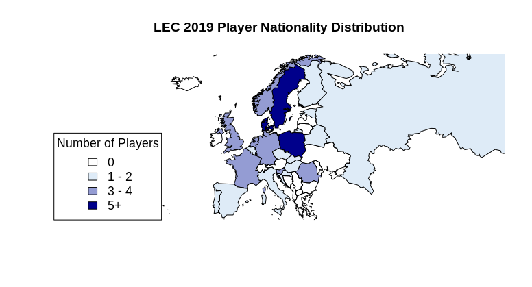

```python
Image(filename='nationalities.png')
```

```python
df2.head().sort_values('KDA')
```

|  | Player | Team | Pos | GP | W% | K | D | A | KDA | KP | ... | CSD10 | CSPM | CS%P15 | DPM | DMG% | EGPM | Gold% | WPM | WCPM | Split |
| --- | --- | --- | --- | --- | --- | --- | --- | --- | --- | --- | --- | --- | --- | --- | --- | --- | --- | --- | --- | --- | --- |
| 0 | Abbedagge | Schalke 04 | Middle | 19.0 | 47.0 | 41.0 | 43.0 | 79.0 | 2.8 | 63.2 | ... | -3.3 | 9.0 | 26.6 | 417.0 | 24.6 | 257.9 | 22.5 | 0.51 | 0.19 | Spring Regular |
| 4 | Bwipo | Fnatic | Top | 18.0 | 61.0 | 41.0 | 42.0 | 80.0 | 2.9 | 56.8 | ... | -10.0 | 7.6 | 23.6 | 444.0 | 25.5 | 239.7 | 20.4 | 0.48 | 0.16 | Spring Regular |
| 1 | Alphari | Origen | Top | 18.0 | 67.0 | 29.0 | 30.0 | 73.0 | 3.4 | 51.8 | ... | 1.7 | 8.0 | 22.4 | 354.0 | 21.8 | 243.5 | 20.9 | 0.54 | 0.15 | Spring Regular |
| 2 | Attila | Vitality | ADC | 18.0 | 56.0 | 48.0 | 30.0 | 77.0 | 4.2 | 60.1 | ... | -3.9 | 10.2 | 33.4 | 458.0 | 25.6 | 316.7 | 26.9 | 0.35 | 0.39 | Spring Regular |
| 3 | Broxah | Fnatic | Jungle | 18.0 | 61.0 | 49.0 | 27.0 | 93.0 | 5.3 | 66.7 | ... | -1.8 | 5.0 | 13.2 | 255.0 | 14.9 | 200.1 | 17.1 | 0.36 | 0.34 | Spring Regular |

5 rows × 24 columns

## Player Experience

Another thing that the league prides itself on is the integration of rookie players, players who haven't played professionally before. The European League scene has a thriving set of second division leagues and the majority of orgs are comfortable giving chances to unproven talent

```python
years = [0,2,1,2,1,4,1,2,0,1,2,3,4,0,6,2,2,0,4,4,1,5,0,1,5,8,3,4,3,3,3,6,3,0,0,1,6,4,0,1,3,3,2,4,7,0,0,3,8,0,1,5,4,2,4,3,2,0,0,2,4,0,0,3,0,0,0,4,1,0,4,5,0]
x = Counter(years)

fig = go.Figure(go.Pie(labels=["%s yr" % i for i in sorted(x.keys())],values=[x[i] for i in sorted(x.keys())],sort=False))
fig.update_layout(title_text="Years since Major Region Debut")
fig.show()
```

[interactive chart not shown]

As we can see, fewer than half of the league's players in 2019 had their debut before 2017. Additionally, over a quarter of all players had no experience in major regions before featuring this year. With 10 new rookies already announced for the 2020 season, the future is looking up for the LEC.

```python
x = df2[['Player','Split']].groupby('Split').count().iloc[[2,4]]
fig = go.Figure(go.Bar(x = x.index,
                       y = list(x['Player']),
                      marker_color = "#6baed6"))

fig.update_layout(title_text = "Number of Players per Split")
fig.update_yaxes(title_text="Number of Players")

fig.show()
```

[interactive chart not shown]

## AD Carries

ADCs tend to be fed the most amount of gold throughout the game and are responsible for a large chunk of the teamfight damage. I wanted to explore how efficiently ADCs used the gold share they were given. The graph below shows how much of their team's damage they did compared to how much of the team's gold they got. Ideally you want your adc to deal as much damage as possible.

```python
years = [0,2,1,2,1,4,1,2,0,1,2,3,4,0,6,2,2,0,4,4,1,5,0,1,5,8,3,4,3,3,3,6,3,0,0,1,6,4,0,1,3,3,2,4,7,0,0,3,8,0,1,5,4,2,4,3,2,0,0,2,]
```

```python
fig = px.scatter(x=adcs['Gold%'],
                 y=adcs['DMG%'],
                 color=adcs['Split'],
                 hover_name=adcs['Player'])
fig.update_xaxes(title_text="Gold%",range=[35,15])
fig.update_yaxes(title_text="Damage%")
fig.update_layout(title_text="ADC Gold Efficiency")
fig.show()
```

[interactive chart not shown]

## Midlaners

```python
fig = px.scatter(y=mids['GD10'],
                 x = mids['XPD10'],
                hover_name = mids['Player'],
                color = mids['Split'])

fig.update_xaxes(title_text="XP Difference at 10")
fig.update_yaxes(title_text="Gold Difference at 10")
fig.update_layout(title_text=" Midlaner Laning Dominance")
fig.show()
```

[interactive chart not shown]

## Supports

Supports are the utility members of the team. They take no gold and are usually responsible for engaging/vision control. Vision has been a key part of the meta since the game began and supports have always been at the heart of it. Vision gives information, information wins games. Here we look at how much vision control supports have by looking at their average number of wards placed every minute versus the average number of enemy wards destroyed every minute.

```python
fig = px.scatter(x=sups['WPM'],
                 y=sups['WCPM'],
                 color=sups['Split'],
                 hover_name=sups['Player'])
fig.update_xaxes(title_text="Wards Placed Per Minute")
fig.update_yaxes(title_text="Wards Cleared Per Minute")
fig.update_layout(title_text="Support Vision Control")
fig.show()
```

[interactive chart not shown]

```python
time_splits = df3.columns[[14,17,20,23,26,29]]
times = pd.DataFrame(index = time_splits, columns = ["Spring","Summer"])
grouped_df3 = df3.groupby('Split').sum()
for i in time_splits:
    times['Spring'][i] = (grouped_df3[i][0] / 10) / 107
    times['Summer'][i] = (grouped_df3[i][1] / 10) / 114

times.columns
time_splits = [i.replace("games","minutes") for i in time_splits]
```

## Game Time

This year has been described as having one of the fastest metas in history. Teams were constantly winning games before 30 minutes, a far cry from the snoozefest of 5 years ago

```python
fig = go.Figure(data=[
    go.Bar(name='Spring', x=time_splits, y=times['Spring']),
    go.Bar(name='Summer', x=time_splits, y=times['Summer'])
])
fig.update_layout(title_text = "Game Length: Spring v Summer Split")
fig.update_yaxes(title_text = "Percentage of Games")
fig.show()
```

[interactive chart not shown]

As we can see, the majority of games were finished before the 35 minute mark, while there were fewer games longer than 40 minutes in the Summer split. It seems that teams improved heavily on quickly closing out games in the second half of the year

```python
champs = df3[['Champion 1','∑ 2','W 3','L 4']].groupby('Champion 1').sum().sort_values("∑ 2",ascending = False)
```

```python
x = df3[['W 3','Split']].groupby('Split').count()

fig = go.Figure(go.Bar(x = x.index,
                       y = list(x['W 3']),
                      marker_color = "#f768a1"))

fig.update_layout(title_text = "Number of Unique Champions per Split")
fig.update_yaxes(title_text="Number of Champions")

fig.show()
```

[interactive chart not shown]

## Champions

Champions are one of the most important part of the game, each player gets to choose one character with unique abilities to play the game as. Here we explore some of the basic graphs about these champions

```python
fig = go.Figure(data=[
    go.Bar(name='Wins',
           x=champs.index[range(10)],
           y=champs['W 3'],
           marker_color = "#1c9099",
           textposition="auto"),


    go.Bar(name='Losses',
           x=champs.index[range(10)],
           y=champs['L 4'],
           marker_color = "#a6bddb",
           textposition = "auto",
            text = champs['∑ 2']),

])
fig.update_yaxes(title_text = "Number of Games")
fig.update_layout(
    barmode='stack',
    title = "Most Picked Champions: Spring & Summer Split",
    font=dict(
        family="Calibri, monospace",
        size=16,
        color="#7f7f7f")
                 )
fig.show()
```

[interactive chart not shown]

```python
champs['WR'] = champs['W 3'] / champs['∑ 2']
champs = champs[champs['∑ 2'] > 10].sort_values('WR',ascending = False)

fig = go.Figure(data=[
    go.Bar(name='Winrate',
           x=champs.index[range(10)],
           y=champs['WR'],
           marker_color = "#fec44f",
           textposition="auto",
          text=["%s%%" % round(100*champs['WR'].iloc[i],1) for i in range(10)]),
])
fig.update_yaxes(title_text = "Win Percentage")
fig.update_layout(
    barmode='stack',
    title = "Highest Winrate Champions: Spring & Summer Split (Min 10 Games)",
    font=dict(
        family="Calibri, monospace",
        size=16,
        color="#7f7f7f")
                 )
fig.show()
```

[interactive chart not shown]

```python
champs = champs[champs['∑ 2'] > 10].sort_values('WR')
fig = go.Figure(data=[
    go.Bar(name='Winrate',
           x=champs.index[range(10)],
           y=champs['WR'],
           marker_color = "#78c679",
           textposition="auto",
          text=["%s%%" % round(100*champs['WR'].iloc[i],1) for i in range(10)]),
])
fig.update_yaxes(title_text = "Win Percentage")
fig.update_layout(
    barmode='stack',
    title = "Lowest Winrate Champions: Spring & Summer Split (Min 10 Games)",
    font=dict(
        family="Calibri, monospace",
        size=16,
        color="#7f7f7f")
                 )
fig.show()
```

[interactive chart not shown]

```python
fig = go.Figure(go.Bar(x=["Fnatic","Promisq"],y=[0,2],marker_color="grey"))
fig.update_layout(title_text="Number of LEC Medals")
fig.show()
```

[interactive chart not shown]